# Chulwalhar Flower Exports: Time Series Data Modeling and Forecasting

## ARIMA

AR = Autoregression A Regression of a variable with itself. The autoregressive model specifies that the output variable depends linearly on its own previous values.  
MA = Moving Average The rolling average of past forecast errors. This model should not be confused with moving average smoothing, which is used for establishing trends and is based on past values.  
ARIMA = AutoRegressive Integrated Moving Average model A combination of Differencing, Autoregression and Moving Average. Integration is the opposite of differencing.

Differencing In order to make the time series stationary, it is necessary to difference. Firstly, we need to check if the data are already stationary. This can be done with help of the Augmented Dickey-Fuller Test

```r
adf.test(TotalAsIs, alternative = "stationary")
```

```
##
##  Augmented Dickey-Fuller Test
##
## data:  TotalAsIs
## Dickey-Fuller = -5.8915, Lag order = 4, p-value = 0.01
## alternative hypothesis: stationary
```

```r
#The p-value is less than 0,05. This means that the data is stationary,
# as the 0-Hypothesis of the test is "The data are not stationary".

# Another possibility is the Kwiatkowski-Phillips-Schmidt-Shin Test
kpss.test(TotalAsIs)
```

```
##
##  KPSS Test for Level Stationarity
##
## data:  TotalAsIs
## KPSS Level = 2.0548, Truncation lag parameter = 1, p-value = 0.01
```

```r
# This test swaps the hypothesis so that a low p-value means that it
# is necessary to difference. The p-value here is under 0,01 and a warning
# is shown.

# As the test failed to deliver a clear result, the data will be differenced
# and then retested.

ChulwalarDiff <- diff(TotalAsIs)

adf.test(ChulwalarDiff, alternative = "stationary")
```

```
##
##  Augmented Dickey-Fuller Test
##
## data:  ChulwalarDiff
## Dickey-Fuller = -6.2758, Lag order = 4, p-value = 0.01
## alternative hypothesis: stationary
```

```r
kpss.test(ChulwalarDiff)
```

```
##
##  KPSS Test for Level Stationarity
##
## data:  ChulwalarDiff
## KPSS Level = 0.024179, Truncation lag parameter = 1, p-value = 0.1
```

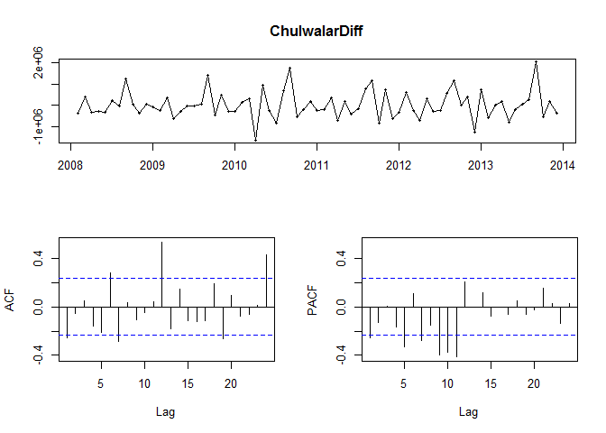

```r
# The kpss.test now has a p-value of more than 0,1, which hints that the data
# is stationary.

tsdisplay(ChulwalarDiff)
```

```r
# However this plot shows that the months correlate stongly with the values
# from the previous year. This plot shows a  ACF
# (autocorrelation function) and a PACF (partial autocorrelation function).

# The folling is a test method to distinguish the number of "normal"
# differencing rounds and seasonal differencing rounds.
# Seasonal differencing is used for data which is dominated by seasonality.
# The time series has been assigned a lag.

ns <- nsdiffs(TotalAsIs)
if(ns > 0) {
  xstar <- diff(TotalAsIs,lag=frequency(TotalAsIs),differences=ns)
} else {
  xstar <- TotalAsIs
}
nd <- ndiffs(xstar)
if(nd > 0) {
  xstar <- diff(xstar,differences=nd)
}

nd # Number of normal differencing rounds
```

```
## [1] 0
```

```r
ns # Number of seasonal differencing rounds
```

```
## [1] 1
```

```r
xstar # The output "xstar" has been differenced correctly.
```

```
##          Jan     Feb     Mar     Apr     May     Jun     Jul     Aug
## 2009  297352  421196  397151   85521   93109  377920  117674  212298
## 2010  150115  547006  483255 -511420  700084  481423 -323167  296553
## 2011  352173    8330   67743  963191  223911   60582  748756  843266
## 2012  -19773  752645  138580  137820  237699  347801  260934   63868
## 2013 1026438 -143564  127610 1045166  -51834   61870  344910   28458
##          Sep     Oct     Nov     Dec
## 2009  388285 -140828  714282  365945
## 2010  627400  530065 -174831  310373
## 2011  252960  -30269  901131   96957
## 2012   49265  910040  581464  -46170
## 2013  906979  333420  110773  988508
```

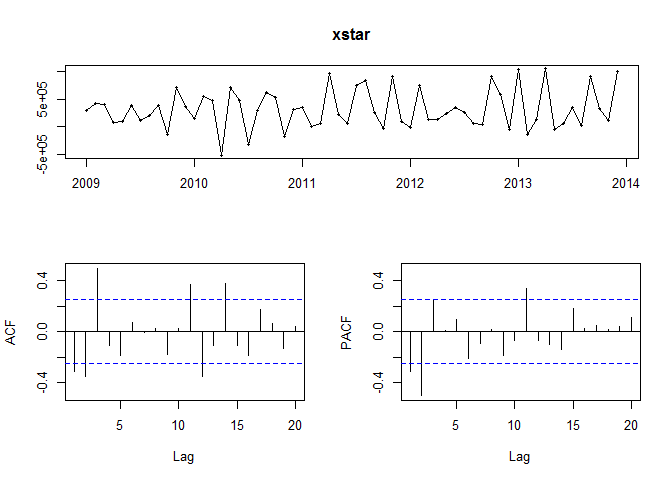

```r
tsdisplay(xstar)
```

```r
# If "lag" is set to 12, this is equivalent to 1* seasonal differencing
ChulwalarDiff_lag <- diff(TotalAsIs,lag=12)

adf.test(ChulwalarDiff_lag, alternative = "stationary")
```

```
##
##  Augmented Dickey-Fuller Test
##
## data:  ChulwalarDiff_lag
## Dickey-Fuller = -4.0902, Lag order = 3, p-value = 0.01175
## alternative hypothesis: stationary
```

```r
kpss.test(ChulwalarDiff_lag)
```

```
##
##  KPSS Test for Level Stationarity
##
## data:  ChulwalarDiff_lag
## KPSS Level = 0.13387, Truncation lag parameter = 1, p-value = 0.1
```

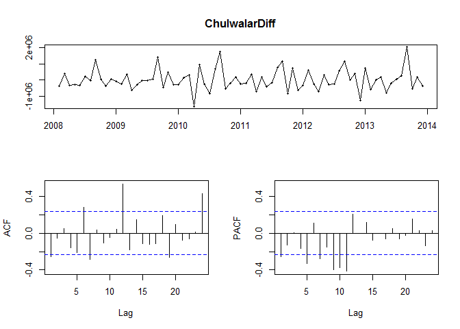

```r
tsdisplay(ChulwalarDiff)
```

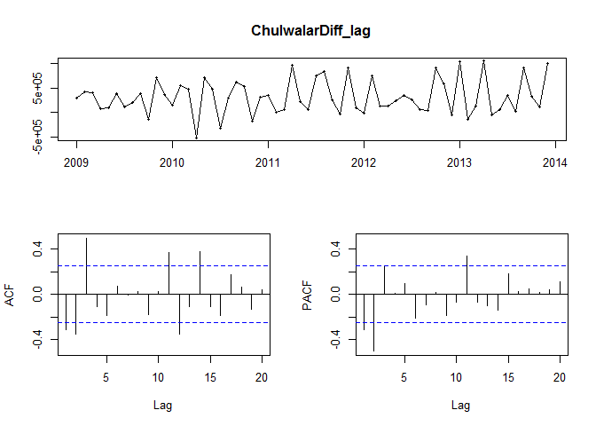

```r
tsdisplay(ChulwalarDiff_lag)
```

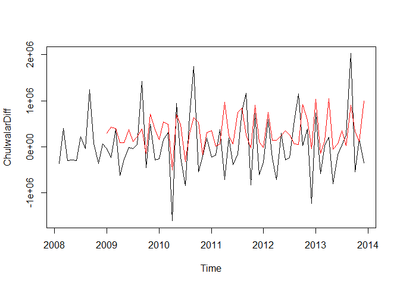

```r
plot(ChulwalarDiff)
lines(ChulwalarDiff_lag, col="red")
```

```r
# The time series appears much more "stationary".
```

### ARIMA modeling

The values for AIC, AICc and BIC should be minimised. We wil try a range of combinations. R uses the maximum likelihood estimation (MLE) in order to decide how good a certain model is. The parameters, which give the most likely model based on the given data, are chosen. Furthermore, R gives the log-likelihood, which should be maximised.

```r
Model_ARIMA_1  <- Arima(TotalAsIs, order=c(0,1,0))
summary(Model_ARIMA_1 )
```

```
## Series: TotalAsIs
## ARIMA(0,1,0)
##
## sigma^2 estimated as 4.097e+11:  log likelihood=-1049.96
## AIC=2101.93   AICc=2101.99   BIC=2104.19
##
## Training set error measures:
##                    ME     RMSE      MAE       MPE     MAPE    MASE
## Training set 28628.79 635581.2 472471.7 -1.605296 16.44154 1.28785
##                    ACF1
## Training set -0.2573856
```

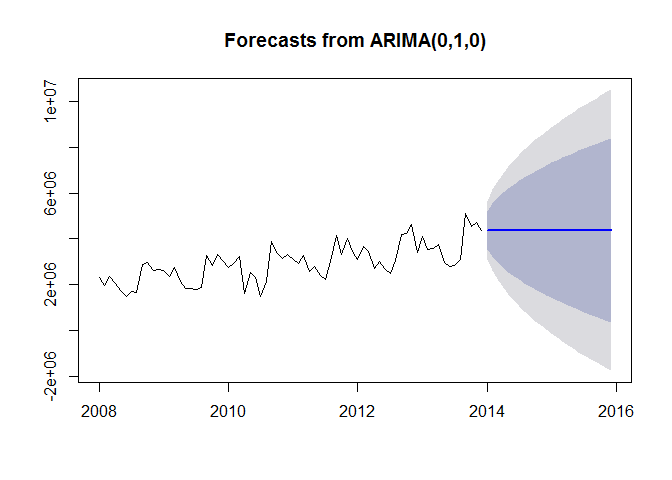

```r
plot(forecast(Model_ARIMA_1 ))
```

```r
#AIC=2101.93   AICc=2101.99   BIC=2104.19

Model_ARIMA_2 <- Arima(TotalAsIs, order=c(1,1,0))
summary(Model_ARIMA_2)
```

```
## Series: TotalAsIs
## ARIMA(1,1,0)
##
## Coefficients:
##           ar1
##       -0.2531
## s.e.   0.1144
##
## sigma^2 estimated as 3.884e+11:  log likelihood=-1047.6
## AIC=2099.2   AICc=2099.38   BIC=2103.72
##
## Training set error measures:
##                    ME     RMSE      MAE       MPE     MAPE     MASE
## Training set 37287.11 614478.1 430163.6 -1.639433 15.09104 1.172528
##                     ACF1
## Training set -0.03792494
```

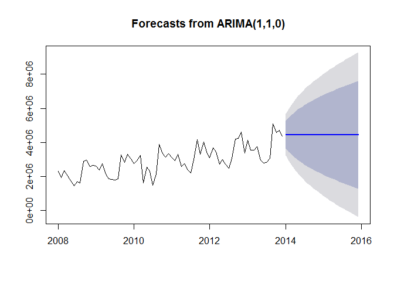

```r
plot(forecast(Model_ARIMA_2))
```

```r
#AIC=2099.2   AICc=2099.38   BIC=2103.72

Model_ARIMA_3 <- Arima(TotalAsIs, order=c(1,1,1))
summary(Model_ARIMA_3)
```

```
## Series: TotalAsIs
## ARIMA(1,1,1)
##
## Coefficients:
##          ar1      ma1
##       0.5013  -0.8940
## s.e.  0.1225   0.0523
##
## sigma^2 estimated as 3.483e+11:  log likelihood=-1043.55
## AIC=2093.09   AICc=2093.45   BIC=2099.88
##
## Training set error measures:
##                    ME     RMSE    MAE       MPE     MAPE     MASE
## Training set 108896.1 577776.4 418339 0.1597019 14.59994 1.140297
##                     ACF1
## Training set -0.04946106
```

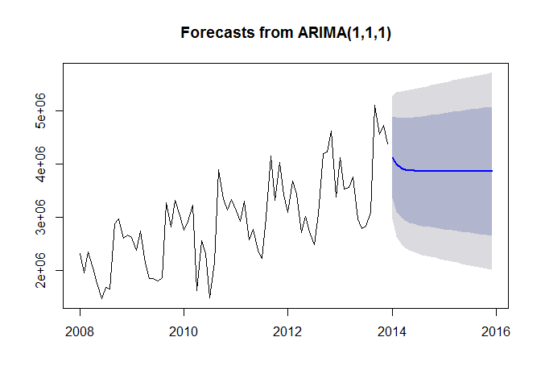

```r
plot(forecast(Model_ARIMA_3))
```

```r
#AIC=2093.09   AICc=2093.45   BIC=2099.88

Model_ARIMA_4 <- Arima(TotalAsIs, order=c(2,1,1))
summary(Model_ARIMA_4)
```

```
## Series: TotalAsIs
## ARIMA(2,1,1)
##
## Coefficients:
##          ar1     ar2      ma1
##       0.4960  0.0162  -0.8958
## s.e.  0.1292  0.1244   0.0538
##
## sigma^2 estimated as 3.534e+11:  log likelihood=-1043.54
## AIC=2095.08   AICc=2095.68   BIC=2104.13
##
## Training set error measures:
##                    ME     RMSE      MAE       MPE     MAPE     MASE
## Training set 108259.9 577759.6 416830.2 0.1419833 14.54368 1.136184
##                     ACF1
## Training set -0.04006432
```

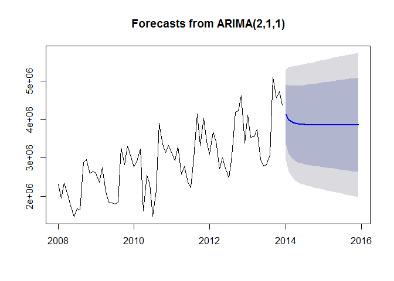

```r
plot(forecast(Model_ARIMA_4))
```

```r
#AIC=2095.08   AICc=2095.68   BIC=2104.13

Model_ARIMA_5 <- Arima(TotalAsIs, order=c(2,1,2))
summary(Model_ARIMA_5)
```

```
## Series: TotalAsIs
## ARIMA(2,1,2)
##
## Coefficients:
##           ar1     ar2     ma1      ma2
##       -0.4308  0.5690  0.0939  -0.8951
## s.e.   0.1195  0.1195  0.0544   0.0537
##
## sigma^2 estimated as 3.211e+11:  log likelihood=-1040.54
## AIC=2091.07   AICc=2092   BIC=2102.39
##
## Training set error measures:
##                    ME     RMSE      MAE       MPE     MAPE     MASE
## Training set 101551.5 546638.3 407424.5 0.1950065 14.29599 1.110546
##                    ACF1
## Training set 0.01796927
```

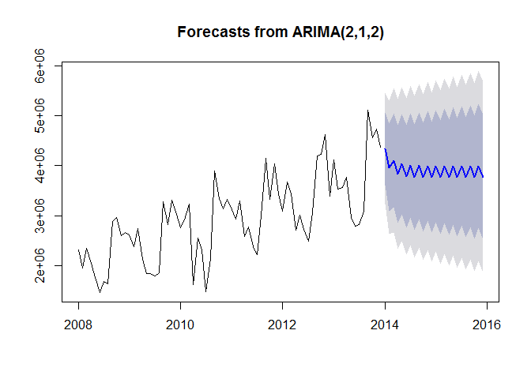

```r
plot(forecast(Model_ARIMA_5))
```

```r
#AIC=2091.07   AICc=2092   BIC=2102.39

Model_ARIMA_6 <- Arima(TotalAsIs, order=c(3,1,2))
summary(Model_ARIMA_6)
```

```
## Series: TotalAsIs
## ARIMA(3,1,2)
##
## Coefficients:
##           ar1     ar2      ar3     ma1      ma2
##       -0.3893  0.5013  -0.1092  0.1083  -0.8830
## s.e.   0.1284  0.1385   0.1231  0.0569   0.0566
##
## sigma^2 estimated as 3.207e+11:  log likelihood=-1040.15
## AIC=2092.3   AICc=2093.61   BIC=2105.87
##
## Training set error measures:
##                    ME     RMSE      MAE       MPE     MAPE     MASE
## Training set 104678.5 542170.4 409442.9 0.3156703 14.41613 1.116048
##                     ACF1
## Training set -0.03533504
```

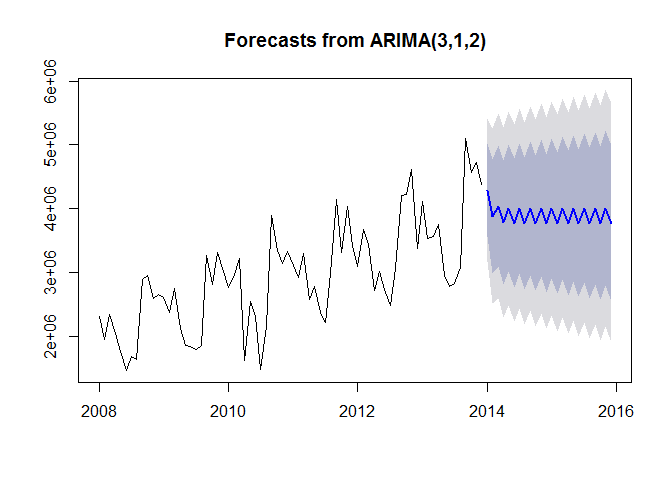

```r
plot(forecast(Model_ARIMA_6))
```

```r
#AIC=2092.3   AICc=2093.61   BIC=2105.87

Model_ARIMA_7 <- Arima(TotalAsIs, order=c(3,1,3))
summary(Model_ARIMA_7)
```

```
## Series: TotalAsIs
## ARIMA(3,1,3)
##
## Coefficients:
##           ar1      ar2     ar3     ma1     ma2      ma3
##       -0.3899  -0.3992  0.5784  0.0121  0.1473  -0.8863
## s.e.   0.2719   0.2546  0.1245  0.5756  0.2820   0.6757
##
## sigma^2 estimated as 3.243e+11:  log likelihood=-1040.01
## AIC=2094.03   AICc=2095.81   BIC=2109.87
##
## Training set error measures:
##                    ME   RMSE      MAE       MPE     MAPE     MASE
## Training set 98929.36 541073 383116.9 0.2717968 13.13481 1.044289
##                     ACF1
## Training set 0.006450566
```

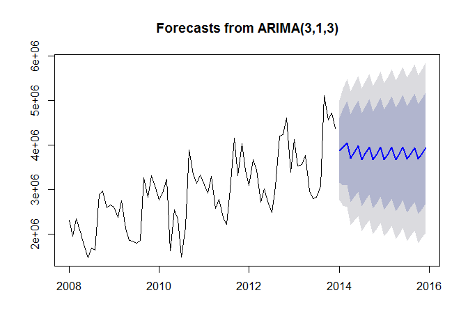

```r
plot(forecast(Model_ARIMA_7))
```

```r
#AIC=2094.03   AICc=2095.81   BIC=2109.87

Model_ARIMA_8 <- Arima(TotalAsIs, order=c(3,1,1))
summary(Model_ARIMA_8)
```

```
## Series: TotalAsIs
## ARIMA(3,1,1)
##
## Coefficients:
##          ar1     ar2      ar3      ma1
##       0.4861  0.0501  -0.0876  -0.8861
## s.e.  0.1284  0.1321   0.1224   0.0558
##
## sigma^2 estimated as 3.557e+11:  log likelihood=-1043.29
## AIC=2096.57   AICc=2097.5   BIC=2107.89
##
## Training set error measures:
##                    ME     RMSE      MAE       MPE     MAPE     MASE
## Training set 112288.1 575349.1 416026.3 0.2735252 14.58788 1.133993
##                     ACF1
## Training set -0.06722377
```

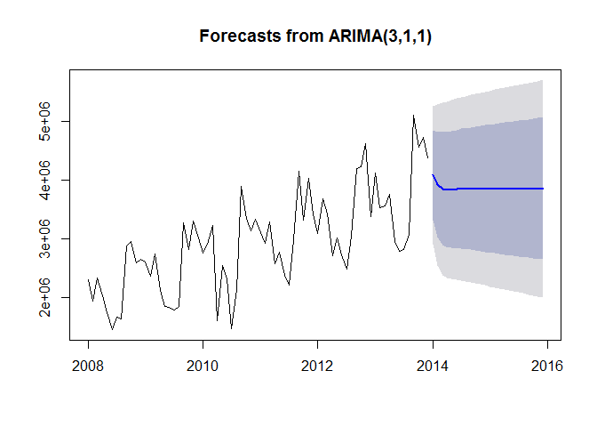

```r
plot(forecast(Model_ARIMA_8))
```

```r
#AIC=2096.57   AICc=2097.5   BIC=2107.89

Model_ARIMA_9 <- Arima(TotalAsIs, order=c(3,1,2))
summary(Model_ARIMA_9)
```

```
## Series: TotalAsIs
## ARIMA(3,1,2)
##
## Coefficients:
##           ar1     ar2      ar3     ma1      ma2
##       -0.3893  0.5013  -0.1092  0.1083  -0.8830
## s.e.   0.1284  0.1385   0.1231  0.0569   0.0566
##
## sigma^2 estimated as 3.207e+11:  log likelihood=-1040.15
## AIC=2092.3   AICc=2093.61   BIC=2105.87
##
## Training set error measures:
##                    ME     RMSE      MAE       MPE     MAPE     MASE
## Training set 104678.5 542170.4 409442.9 0.3156703 14.41613 1.116048
##                     ACF1
## Training set -0.03533504
```

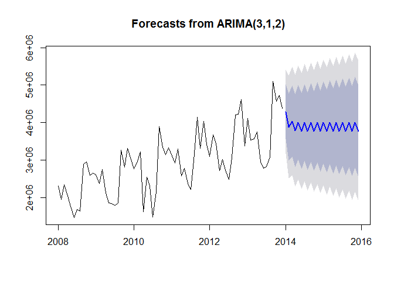

```r
plot(forecast(Model_ARIMA_9))
```

```r
#AIC=2092.3   AICc=2093.61   BIC=2105.87

Model_ARIMA_10 <- Arima(TotalAsIs, order=c(1,1,3))
summary(Model_ARIMA_10)
```

```
## Series: TotalAsIs
## ARIMA(1,1,3)
##
## Coefficients:
##          ar1      ma1     ma2      ma3
##       0.4527  -0.8779  0.0965  -0.1023
## s.e.  0.2410   0.2408  0.2460   0.1621
##
## sigma^2 estimated as 3.567e+11:  log likelihood=-1043.34
## AIC=2096.69   AICc=2097.61   BIC=2108
##
## Training set error measures:
##                    ME   RMSE      MAE       MPE     MAPE     MASE
## Training set 108260.8 576125 411814.8 0.1681833 14.39459 1.122513
##                     ACF1
## Training set -0.02687555
```

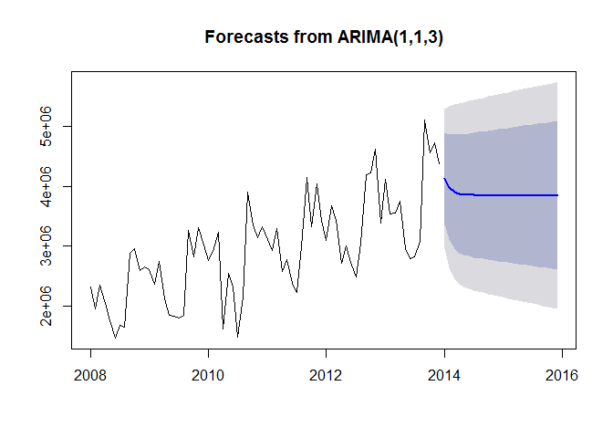

```r
plot(forecast(Model_ARIMA_10))
```

```r
#AIC=2096.69   AICc=2097.61   BIC=2108

Model_ARIMA_11 <- Arima(TotalAsIs, order=c(2,1,3))
summary(Model_ARIMA_11)
```

```
## Series: TotalAsIs
## ARIMA(2,1,3)
##
## Coefficients:
##           ar1      ar2     ma1      ma2      ma3
##       -1.1981  -0.1982  1.1439  -0.6940  -0.8420
## s.e.   0.1350   0.1350  0.1239   0.1394   0.1099
##
## sigma^2 estimated as 2.64e+11:  log likelihood=-1036.61
## AIC=2085.22   AICc=2086.53   BIC=2098.8
##
## Training set error measures:
##                 ME   RMSE      MAE       MPE     MAPE     MASE        ACF1
## Training set 96418 491927 381028.7 0.4152085 13.44772 1.038597 0.003938262
```

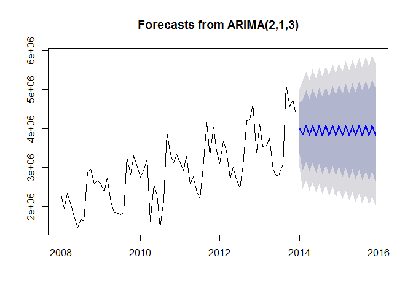

```r
plot(forecast(Model_ARIMA_11))
```

```r
#AIC=2085.22   AICc=2086.53   BIC=2098.8

Model_ARIMA_12 <- Arima(TotalAsIs, order=c(2,2,3))
summary(Model_ARIMA_12)
```

```
## Series: TotalAsIs
## ARIMA(2,2,3)
##
## Coefficients:
##           ar1     ar2      ma1      ma2     ma3
##       -0.4575  0.5423  -0.9992  -0.9842  0.9938
## s.e.   0.1097  0.1097   0.0600   0.0468  0.0596
##
## sigma^2 estimated as 2.933e+11:  log likelihood=-1026.69
## AIC=2065.39   AICc=2066.72   BIC=2078.88
##
## Training set error measures:
##                    ME     RMSE      MAE       MPE     MAPE     MASE
## Training set 32207.69 514572.7 390086.2 -1.782274 13.95983 1.063286
##                   ACF1
## Training set 0.0523144
```

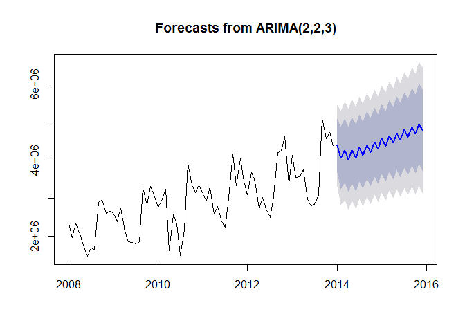

```r
plot(forecast(Model_ARIMA_12))
```

```r
#AIC=2065.39   AICc=2066.72   BIC=2078.88

Model_ARIMA_13 <- Arima(TotalAsIs, order=c(2,3,2))
summary(Model_ARIMA_13)
```

```
## Series: TotalAsIs
## ARIMA(2,3,2)
##
## Coefficients:
##           ar1      ar2      ma1     ma2
##       -0.2556  -0.0955  -1.9949  0.9998
## s.e.   0.1213   0.1203   0.0568  0.0565
##
## sigma^2 estimated as 4.154e+11:  log likelihood=-1025.64
## AIC=2061.27   AICc=2062.22   BIC=2072.44
##
## Training set error measures:
##                     ME     RMSE    MAE       MPE     MAPE     MASE
## Training set -18789.17 612404.9 442164 -3.108129 15.40378 1.205238
##                    ACF1
## Training set -0.0160389
```

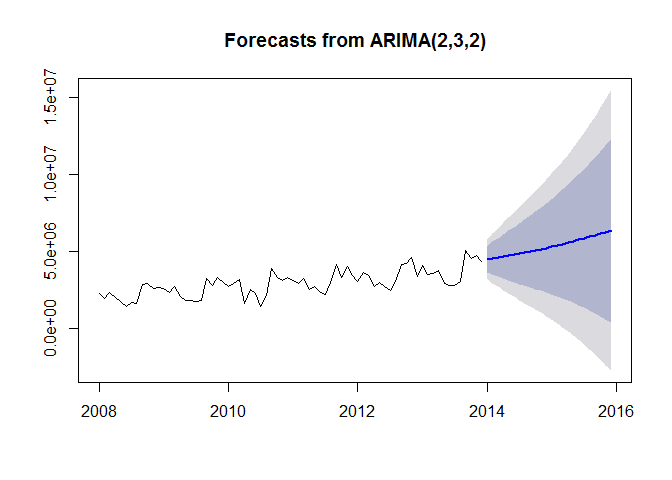

```r
plot(forecast(Model_ARIMA_13))
```

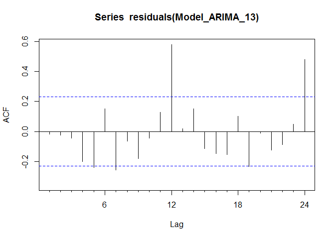

```r
#AIC=2061.27   AICc=2062.22   BIC=2072.44

Acf(residuals(Model_ARIMA_13))
```

```r
Box.test(residuals(Model_ARIMA_13), lag=12, fitdf=4, type="Ljung")
```

```
##
##  Box-Ljung test
##
## data:  residuals(Model_ARIMA_13)
## X-squared = 49.513, df = 8, p-value = 5.068e-08
```

```r
# The Ljung-Box Test has H0: The data are independently distributed
# und Ha: The data are not independently distributed.

# Just like the remainder showed before, there is a definite coherence#
```

### Seasonal ARIMA modeling

This model integrates the seasonal aspect into the ARIMA model. As the previous models all had a peak in lag 12, it seems viable that the data are seasonal.

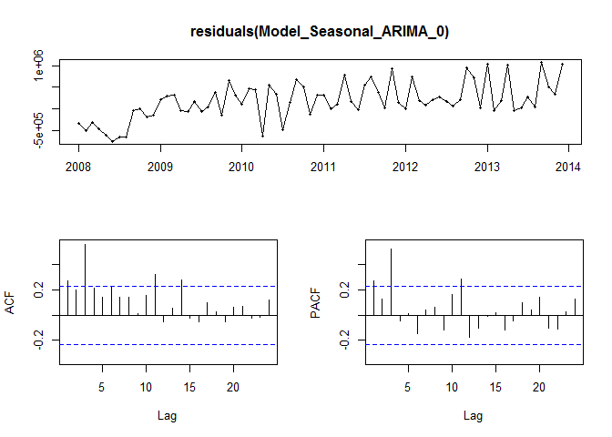

```r
Model_Seasonal_ARIMA_0 <- Arima(TotalAsIs, order=c(0,0,0), seasonal=c(1,0,0))
tsdisplay(residuals(Model_Seasonal_ARIMA_0))
```

```r
summary(Model_Seasonal_ARIMA_0)
```

```
## Series: TotalAsIs
## ARIMA(0,0,0)(1,0,0)[12] with non-zero mean
##
## Coefficients:
##         sar1  intercept
##       0.8670  2972908.7
## s.e.  0.0496   230693.3
##
## sigma^2 estimated as 2.211e+11:  log likelihood=-1049.89
## AIC=2105.79   AICc=2106.14   BIC=2112.62
##
## Training set error measures:
##                    ME     RMSE    MAE      MPE     MAPE     MASE      ACF1
## Training set 178628.1 463638.5 354855 3.056776 12.76901 0.967254 0.2749878
```

```r
#AIC=2105.79   AICc=2106.14   BIC=2112.62

Model_Seasonal_ARIMA_1 <- Arima(TotalAsIs, order=c(0,1,1), seasonal=c(0,1,1))
summary(Model_Seasonal_ARIMA_1)
```

```
## Series: TotalAsIs
## ARIMA(0,1,1)(0,1,1)[12]
##
## Coefficients:
##           ma1     sma1
##       -0.9999  -0.7599
## s.e.   0.1180   0.3144
##
## sigma^2 estimated as 8.71e+10:  log likelihood=-833.44
## AIC=1672.88   AICc=1673.31   BIC=1679.11
##
## Training set error measures:
##                    ME     RMSE      MAE        MPE     MAPE      MASE
## Training set 27419.53 262591.5 185283.1 -0.2676759 6.296359 0.5050396
##                    ACF1
## Training set -0.2913248
```

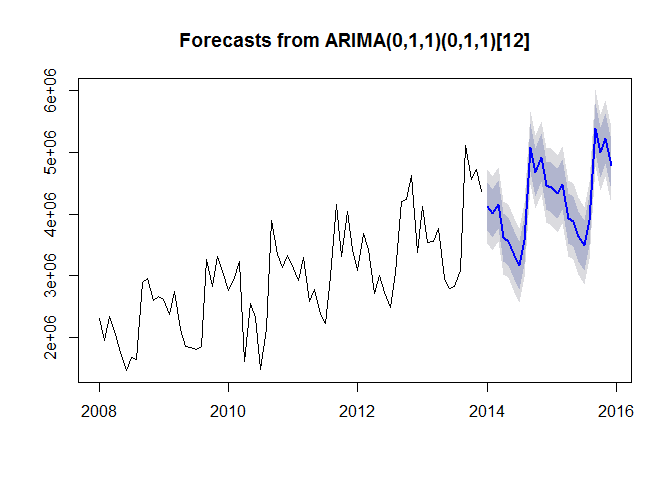

```r
plot(forecast(Model_Seasonal_ARIMA_1))
```

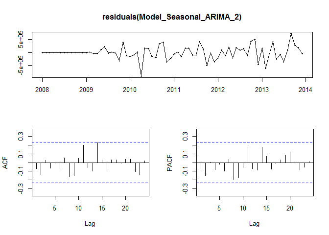

```r
#AIC=1672.88   AICc=1673.31   BIC=1679.11

# Insert the values from the previous chapter for the non-seasonal values.
Model_Seasonal_ARIMA_2 <- Arima(TotalAsIs, order=c(2,3,2), seasonal=c(1,1,1))
tsdisplay(residuals(Model_Seasonal_ARIMA_2))
```

```r
summary(Model_Seasonal_ARIMA_2)
```

```
## Series: TotalAsIs
## ARIMA(2,3,2)(1,1,1)[12]
##
## Coefficients:
##           ar1      ar2      ma1     ma2     sar1     sma1
##       -0.8870  -0.7259  -1.9692  0.9977  -0.1289  -0.5091
## s.e.   0.0876   0.0907   0.0699  0.0697   0.2692   0.3059
##
## sigma^2 estimated as 9.302e+10:  log likelihood=-808.11
## AIC=1630.23   AICc=1632.51   BIC=1644.53
##
## Training set error measures:
##                     ME     RMSE      MAE        MPE     MAPE      MASE
## Training set -5252.206 256693.1 176056.7 -0.8935257 5.910925 0.4798906
##                     ACF1
## Training set -0.07108056
```

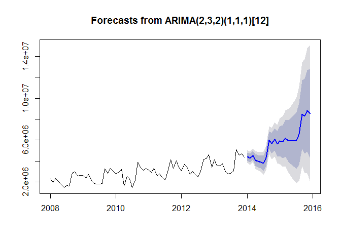

```r
plot(forecast(Model_Seasonal_ARIMA_2))
```

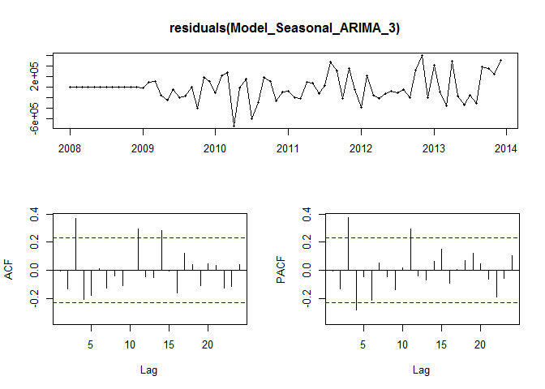

```r
# AIC=1630.23   AICc=1632.51   BIC=1644.53

# Good results when using drift.
Model_Seasonal_ARIMA_3 <- Arima(TotalAsIs, order=c(1,0,1), seasonal=c(1,1,1),include.drift=TRUE)
tsdisplay(residuals(Model_Seasonal_ARIMA_3))
```